# Module 131

#### Hemi-module gene counts:

151 probesets in hemi-module A.  
171 probesets in hemi-module B.  
Note: While the mapping of probesets to genes is usually one-to-one, some genes are targeted by multiple probesets, some probesets target multiple genes, and some probesets do not target any genes (i.e., the region of the genome they match is no longer considered genic).

#### Contrast SVE:

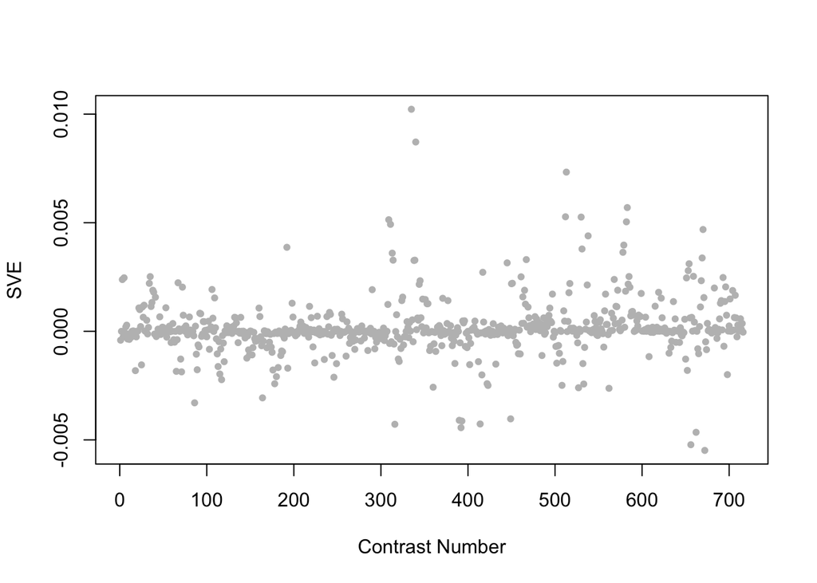

Positive SVE Contrasts:

|  | Contrast.Num | SVE | GEO.GSE | Cond.1 | Cond.2 | Mutation |
| --- | --- | --- | --- | --- | --- | --- |
| GSE38997.s3t2.vs.s2t2 | 335 | 0.01 | GSE38997 | experiment 4 UVC- and EtBr-exposed samples at 24 h 4eu24 | experiment 4 EtBr-exposed samples at 24 h 4e24 |  |
| GSE38997.s4t1.vs.s1t1 | 340 | 0.01 | GSE38997 | experiment 4 UVC-exposed samples at 3 h 4u3 | experiment 4 control samples at 3 h 4c3 |  |
| GSE2180.s4t1.vs.s2t1 | 513 | 0.01 | GSE2180 | pp0-1 | ms0-1 |  |
| GSE2180.s2t3.vs.s2t1 | 583 | 0.01 | GSE2180 | ms41-1 | ms0-1 |  |
| GSE2180.s3t1.vs.s2t1 | 512 | 0.01 | GSE2180 | p0-3 | ms0-1 |  |

Negative SVE Contrasts:

|  | Contrast.Num | SVE | GEO.GSE | Cond.1 | Cond.2 | Mutation |
| --- | --- | --- | --- | --- | --- | --- |
| GSE14640A.s1t1.vs.s0t1 | 672 | -0.01 | GSE14640 | XO_TY2222-E_080307_A | XX_WT-E_080307_A |  |
| GSE16050.s1t1.vs.s0t1 | 656 | -0.01 | GSE16050 | MT_GFPp_rep1 | WT_GFPp_rep1 |  |
| GSE15159.s2t1.vs.s0t1 | 662 | -0.00 | GSE15159 | xpa-1_control_2007_rep1 | N2_control_2007_rep1 | xpa-1 |
| GSE32339.s1t2.vs.s0t2 | 392 | -0.00 | GSE32339 | Adult Mutant, biological rep1 | Adult Wild-type, biological rep1 | nep-1 |
| GSE39252.s1t1.vs.s0t1 | 316 | -0.00 | GSE39252 | xpa-1_rep1 | N2_rep1 | xpa-1 |

$~$

#### Contrast SVE, Up-Regulated Genes Only:

Calculating SVE for up-regulated and down-regulated genes separately may be more informative in many cases than projecting the up- and down- gene sets together. This is due to the fact that the weight distribution of many modules is highly skewed, indicating that only one of the hemi-modules may be biologically meaningful (i.e., a set of genes are strongly correlated by only a few genes (or none) are strongly anti-correlated to that set.)

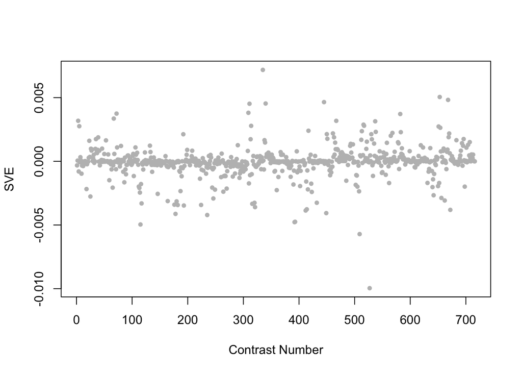

Positive SVE Contrasts:

|  | Contrast.Num | SVE | GEO.GSE | Cond.1 | Cond.2 | Mutation |
| --- | --- | --- | --- | --- | --- | --- |
| GSE38997.s3t2.vs.s2t2 | 335 | 0.01 | GSE38997 | experiment 4 UVC- and EtBr-exposed samples at 24 h 4eu24 | experiment 4 EtBr-exposed samples at 24 h 4e24 |  |
| GSE16405.s4t1.vs.s2t1 | 653 | 0.01 | GSE16405 | xpa-1_1 | nth-1_1 | nth-1 vs. xpa-1 |
| GSE15016.s4t1.vs.s0t1 | 668 | 0.00 | GSE15016 | young adult_24hr BPA exposure_rep1 | young adult_not exposured_rep1 |  |
| GSE27677B.s0t9.vs.s0t7 | 445 | 0.00 | GSE27677 | N2, Fed 48 h, rep 1 | N2, Fed 24 h, rep 1 |  |
| GSE38997.s4t1.vs.s1t1 | 340 | 0.00 | GSE38997 | experiment 4 UVC-exposed samples at 3 h 4u3 | experiment 4 control samples at 3 h 4c3 |  |

Negative SVE Contrasts:

|  | Contrast.Num | SVE | GEO.GSE | Cond.1 | Cond.2 | Mutation |
| --- | --- | --- | --- | --- | --- | --- |
| GSE2180.s2t9.vs.s1t9 | 527 | -0.01 | GSE2180 | ms143-2 | 143L | mex-3(zu155);skn-1(RNAi) |
| GSE2180.s2t1.vs.s1t1 | 509 | -0.01 | GSE2180 | ms0-1 | 00B | mex-3(zu155);skn-1(RNAi) |
| GSE54024.s1t1.vs.s5t1 | 115 | -0.00 | GSE54024 | Wild type young adults, biological rep 1 | ced-4(n1162) young adults, biological rep 1 | ced-4 |
| GSE32339.s1t2.vs.s0t2 | 392 | -0.00 | GSE32339 | Adult Mutant, biological rep1 | Adult Wild-type, biological rep1 | nep-1 |
| GSE32339.s1t1.vs.s0t1 | 393 | -0.00 | GSE32339 | Larval Mutant, biological rep1 | Larval Wild-type, biological rep1 | nep-1 |

$~$

#### Contrast SVE, Down-Regulated Genes Only:

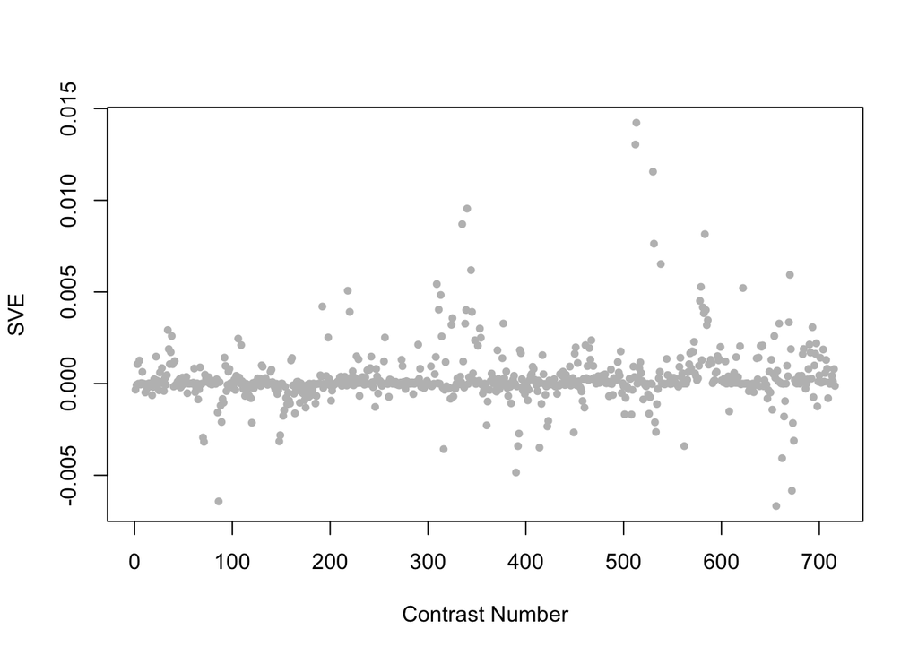

Positive SVE Contrasts:

|  | Contrast.Num | SVE | GEO.GSE | Cond.1 | Cond.2 | Mutation |
| --- | --- | --- | --- | --- | --- | --- |
| GSE2180.s4t1.vs.s2t1 | 513 | 0.01 | GSE2180 | pp0-1 | ms0-1 |  |
| GSE2180.s3t1.vs.s2t1 | 512 | 0.01 | GSE2180 | p0-3 | ms0-1 |  |
| GSE2180.s3t9.vs.s2t9 | 530 | 0.01 | GSE2180 | p143-2 | ms143-2 |  |
| GSE38997.s4t1.vs.s1t1 | 340 | 0.01 | GSE38997 | experiment 4 UVC-exposed samples at 3 h 4u3 | experiment 4 control samples at 3 h 4c3 |  |
| GSE38997.s3t2.vs.s2t2 | 335 | 0.01 | GSE38997 | experiment 4 UVC- and EtBr-exposed samples at 24 h 4eu24 | experiment 4 EtBr-exposed samples at 24 h 4e24 |  |

Negative SVE Contrasts:

|  | Contrast.Num | SVE | GEO.GSE | Cond.1 | Cond.2 | Mutation |
| --- | --- | --- | --- | --- | --- | --- |
| GSE16050.s1t1.vs.s0t1 | 656 | -0.01 | GSE16050 | MT_GFPp_rep1 | WT_GFPp_rep1 |  |
| GSE6547.s1t1.vs.s0t1 | 86 | -0.01 | GSE6547 | lin-35(n745) worms at embryonic stage, first replicate | N2 (wt) worms at embryonic stage, first replicate | lin-35 |
| GSE14640A.s1t1.vs.s0t1 | 672 | -0.01 | GSE14640 | XO_TY2222-E_080307_A | XX_WT-E_080307_A |  |
| GSE32521.s1t1.vs.s0t1 | 390 | -0.00 | GSE32521 | Au-NP Replicate1 | Control Replicate1 |  |
| GSE15159.s2t1.vs.s0t1 | 662 | -0.00 | GSE15159 | xpa-1_control_2007_rep1 | N2_control_2007_rep1 | xpa-1 |

$~$

$~$

#### GO Term Enrichment:

This analysis tests each hemi-module for enrichment of specific GO terms. Only gene-level annotations (e.g., as would be found on the gene’s page in Wormbase) are tested - the hierarchical structure of the GO ontology is not taken into account.

*Note: At least the top two most enriched terms from each GO domain (BP/MF/CC) are shown, even when not statistically significant.*

##### Enriched GO terms: Hemi-module A

| ID | GO.Term | GO Domain | Raw p-value | Adj p-value |
| --- | --- | --- | --- | --- |
| [GO_0098609](http://amigo.geneontology.org/amigo/term/GO:0098609) | cell-cell adhesion | BP | 8.10e-04 | 9.95e-01 |
| [GO_0007016](http://amigo.geneontology.org/amigo/term/GO:0007016) | cytoskeletal anchoring at plasma membrane | BP | 1.45e-03 | 9.95e-01 |
| [GO_0008022](http://amigo.geneontology.org/amigo/term/GO:0008022) | protein C-terminus binding | MF | 7.90e-03 | 9.97e-01 |
| [GO_0005347](http://amigo.geneontology.org/amigo/term/GO:0005347) | ATP transmembrane transporter activity | MF | 8.48e-03 | 9.97e-01 |
| [GO_0008623](http://amigo.geneontology.org/amigo/term/GO:0008623) | CHRAC | CC | 8.48e-03 | 9.96e-01 |
| [GO_0016590](http://amigo.geneontology.org/amigo/term/GO:0016590) | ACF complex | CC | 8.48e-03 | 9.96e-01 |

##### Enriched GO terms: Hemi-module B

| ID | GO.Term | GO Domain | Raw p-value | Adj p-value |
| --- | --- | --- | --- | --- |
| [GO_1902474](http://amigo.geneontology.org/amigo/term/GO:1902474) | positive regulation of protein localization to synapse | BP | 7.14e-04 | 9.94e-01 |
| [GO_0008045](http://amigo.geneontology.org/amigo/term/GO:0008045) | motor neuron axon guidance | BP | 3.27e-03 | 9.94e-01 |
| [GO_0048365](http://amigo.geneontology.org/amigo/term/GO:0048365) | Rac GTPase binding | MF | 2.51e-03 | 9.97e-01 |
| [GO_0015179](http://amigo.geneontology.org/amigo/term/GO:0015179) | L-amino acid transmembrane transporter activity | MF | 3.80e-03 | 9.97e-01 |
| [GO_0070382](http://amigo.geneontology.org/amigo/term/GO:0070382) | exocytic vesicle | CC | 4.53e-03 | 9.96e-01 |
| [GO_0005929](http://amigo.geneontology.org/amigo/term/GO:0005929) | cilium | CC | 6.29e-03 | 9.96e-01 |

$~$

$~$

#### Tissue Enrichment:

This analysis tests each hemi-module for enrichment of genes associated with anatomy terms. Negative enrichment scores indicate fewer hemi-module genes than expected by random chance were associated with the anatomy term in question.

##### Enriched tissues: Hemi-module A

No significant annotations.

##### Enriched tissues: Hemi-module B

| ID | Anatomy.Term | Definition | Raw p-value | Adj p-value |
| --- | --- | --- | --- | --- |
| [WBbt_0003933](https://wormbase.org/species/all/anatomy_term/WBbt:0003933) | AMshR | Embryonic cell of pedigree ABpraapaapp, amphid sheath cell, right. | 1.25e-06 | 1.52e-03 |
| [WBbt_0003935](https://wormbase.org/species/all/anatomy_term/WBbt:0003935) | AMshL | Embryonic cell of pedigree ABplaapaapp, amphid sheath cell, left. | 1.25e-06 | 1.52e-03 |

$~$

$~$

#### HOMER promoter motif enrichment:

This analysis tests each hemi-module for enrichment of 108 known *C. elegans* transcription factor binding site motifs (see [108 CE motifs](https://katiepod.github.io//all.worm.motifs.html)) using the HOMER (Hypergeometric Optimization of Motif EnRichment) software (see [PMID:20513432](https://pubmed.ncbi.nlm.nih.gov/20513432)). HOMER was run using default parameters on sequences 1 kb upstream of the transcription start site.

##### Motif enrichment: Hemi-module A

Total target sequences = 138  
Total background sequences = 40065  
* - possible false positive

Rank

Motif

P-value

log P-pvalue

% of Targets

% of Background

STD(Bg STD)

Best Match/Details

Motif File

1 *

[figure not shown]

1e-10

-2.403e+01

7.25%

0.31%

250.7bp (300.1bp)

PL0002.1_hlh-2::hlh-3/Jaspar(0.565)  
[More Information](https://katiepod.github.io/HomerResults/m131_a_hemi_genes.txt.out.1kb/homerResults/motif1.info.html) | [Similar Motifs Found](https://katiepod.github.io/HomerResults/m131_a_hemi_genes.txt.out.1kb/homerResults/motif1.similar.html)

[motif file (matrix)](https://katiepod.github.io/HomerResults/m131_a_hemi_genes.txt.out.1kb/homerResults/motif1.motif)

2 *

[figure not shown]

1e-9

-2.277e+01

10.14%

0.96%

313.5bp (304.2bp)

fkh-9/MA1440.1/Jaspar(0.545)  
[More Information](https://katiepod.github.io/HomerResults/m131_a_hemi_genes.txt.out.1kb/homerResults/motif2.info.html) | [Similar Motifs Found](https://katiepod.github.io/HomerResults/m131_a_hemi_genes.txt.out.1kb/homerResults/motif2.similar.html)

[motif file (matrix)](https://katiepod.github.io/HomerResults/m131_a_hemi_genes.txt.out.1kb/homerResults/motif2.motif)

3 *

[figure not shown]

1e-9

-2.239e+01

3.62%

0.02%

262.2bp (288.1bp)

efl-1/MA0541.1/Jaspar(0.575)  
[More Information](https://katiepod.github.io/HomerResults/m131_a_hemi_genes.txt.out.1kb/homerResults/motif3.info.html) | [Similar Motifs Found](https://katiepod.github.io/HomerResults/m131_a_hemi_genes.txt.out.1kb/homerResults/motif3.similar.html)

[motif file (matrix)](https://katiepod.github.io/HomerResults/m131_a_hemi_genes.txt.out.1kb/homerResults/motif3.motif)

4 *

[figure not shown]

1e-9

-2.219e+01

8.70%

0.66%

272.8bp (312.4bp)

MF0001.1_ETS_class/Jaspar(0.563)  
[More Information](https://katiepod.github.io/HomerResults/m131_a_hemi_genes.txt.out.1kb/homerResults/motif4.info.html) | [Similar Motifs Found](https://katiepod.github.io/HomerResults/m131_a_hemi_genes.txt.out.1kb/homerResults/motif4.similar.html)

[motif file (matrix)](https://katiepod.github.io/HomerResults/m131_a_hemi_genes.txt.out.1kb/homerResults/motif4.motif)

5 *

[figure not shown]

1e-9

-2.139e+01

7.25%

0.41%

323.2bp (308.2bp)

fkh-2/MA0920.1/Jaspar(0.582)  
[More Information](https://katiepod.github.io/HomerResults/m131_a_hemi_genes.txt.out.1kb/homerResults/motif5.info.html) | [Similar Motifs Found](https://katiepod.github.io/HomerResults/m131_a_hemi_genes.txt.out.1kb/homerResults/motif5.similar.html)

[motif file (matrix)](https://katiepod.github.io/HomerResults/m131_a_hemi_genes.txt.out.1kb/homerResults/motif5.motif)

6 *

[figure not shown]

1e-9

-2.104e+01

5.80%

0.20%

227.5bp (291.6bp)

nhr-6/MA1451.1/Jaspar(0.882)  
[More Information](https://katiepod.github.io/HomerResults/m131_a_hemi_genes.txt.out.1kb/homerResults/motif6.info.html) | [Similar Motifs Found](https://katiepod.github.io/HomerResults/m131_a_hemi_genes.txt.out.1kb/homerResults/motif6.similar.html)

[motif file (matrix)](https://katiepod.github.io/HomerResults/m131_a_hemi_genes.txt.out.1kb/homerResults/motif6.motif)

7 *

[figure not shown]

1e-9

-2.075e+01

7.25%

0.44%

325.0bp (290.4bp)

lin-54/MA1450.1/Jaspar(0.596)  
[More Information](https://katiepod.github.io/HomerResults/m131_a_hemi_genes.txt.out.1kb/homerResults/motif7.info.html) | [Similar Motifs Found](https://katiepod.github.io/HomerResults/m131_a_hemi_genes.txt.out.1kb/homerResults/motif7.similar.html)

[motif file (matrix)](https://katiepod.github.io/HomerResults/m131_a_hemi_genes.txt.out.1kb/homerResults/motif7.motif)

8 *

[figure not shown]

1e-8

-2.045e+01

14.49%

2.69%

309.4bp (307.3bp)

daf-16/MA1446.1/Jaspar(0.619)  
[More Information](https://katiepod.github.io/HomerResults/m131_a_hemi_genes.txt.out.1kb/homerResults/motif8.info.html) | [Similar Motifs Found](https://katiepod.github.io/HomerResults/m131_a_hemi_genes.txt.out.1kb/homerResults/motif8.similar.html)

[motif file (matrix)](https://katiepod.github.io/HomerResults/m131_a_hemi_genes.txt.out.1kb/homerResults/motif8.motif)

9 *

[figure not shown]

1e-8

-1.940e+01

6.52%

0.37%

280.1bp (258.7bp)

PL0011.1_hlh-2::hlh-4/Jaspar(0.547)  
[More Information](https://katiepod.github.io/HomerResults/m131_a_hemi_genes.txt.out.1kb/homerResults/motif9.info.html) | [Similar Motifs Found](https://katiepod.github.io/HomerResults/m131_a_hemi_genes.txt.out.1kb/homerResults/motif9.similar.html)

[motif file (matrix)](https://katiepod.github.io/HomerResults/m131_a_hemi_genes.txt.out.1kb/homerResults/motif9.motif)

10 *

[figure not shown]

1e-8

-1.933e+01

12.32%

2.01%

285.8bp (322.3bp)

POL002.1_INR/Jaspar(0.623)  
[More Information](https://katiepod.github.io/HomerResults/m131_a_hemi_genes.txt.out.1kb/homerResults/motif10.info.html) | [Similar Motifs Found](https://katiepod.github.io/HomerResults/m131_a_hemi_genes.txt.out.1kb/homerResults/motif10.similar.html)

[motif file (matrix)](https://katiepod.github.io/HomerResults/m131_a_hemi_genes.txt.out.1kb/homerResults/motif10.motif)

11 *

[figure not shown]

1e-7

-1.797e+01

2.90%

0.01%

238.4bp (263.2bp)

POL011.1_XCPE1/Jaspar(0.523)  
[More Information](https://katiepod.github.io/HomerResults/m131_a_hemi_genes.txt.out.1kb/homerResults/motif11.info.html) | [Similar Motifs Found](https://katiepod.github.io/HomerResults/m131_a_hemi_genes.txt.out.1kb/homerResults/motif11.similar.html)

[motif file (matrix)](https://katiepod.github.io/HomerResults/m131_a_hemi_genes.txt.out.1kb/homerResults/motif11.motif)

12 *

[figure not shown]

1e-7

-1.771e+01

9.42%

1.21%

276.8bp (306.9bp)

nhr-6/MA1451.1/Jaspar(0.637)  
[More Information](https://katiepod.github.io/HomerResults/m131_a_hemi_genes.txt.out.1kb/homerResults/motif12.info.html) | [Similar Motifs Found](https://katiepod.github.io/HomerResults/m131_a_hemi_genes.txt.out.1kb/homerResults/motif12.similar.html)

[motif file (matrix)](https://katiepod.github.io/HomerResults/m131_a_hemi_genes.txt.out.1kb/homerResults/motif12.motif)

13 *

[figure not shown]

1e-7

-1.749e+01

10.14%

1.48%

218.2bp (318.2bp)

SD0003.1_at_AC_acceptor/Jaspar(0.568)  
[More Information](https://katiepod.github.io/HomerResults/m131_a_hemi_genes.txt.out.1kb/homerResults/motif13.info.html) | [Similar Motifs Found](https://katiepod.github.io/HomerResults/m131_a_hemi_genes.txt.out.1kb/homerResults/motif13.similar.html)

[motif file (matrix)](https://katiepod.github.io/HomerResults/m131_a_hemi_genes.txt.out.1kb/homerResults/motif13.motif)

14 *

[figure not shown]

1e-7

-1.723e+01

15.94%

3.96%

285.0bp (297.1bp)

pqm-1/MA1703.1/Jaspar(0.712)  
[More Information](https://katiepod.github.io/HomerResults/m131_a_hemi_genes.txt.out.1kb/homerResults/motif14.info.html) | [Similar Motifs Found](https://katiepod.github.io/HomerResults/m131_a_hemi_genes.txt.out.1kb/homerResults/motif14.similar.html)

[motif file (matrix)](https://katiepod.github.io/HomerResults/m131_a_hemi_genes.txt.out.1kb/homerResults/motif14.motif)

15 *

[figure not shown]

1e-7

-1.706e+01

7.25%

0.65%

256.3bp (295.4bp)

cebp-1/MA1444.1/Jaspar(0.515)  
[More Information](https://katiepod.github.io/HomerResults/m131_a_hemi_genes.txt.out.1kb/homerResults/motif15.info.html) | [Similar Motifs Found](https://katiepod.github.io/HomerResults/m131_a_hemi_genes.txt.out.1kb/homerResults/motif15.similar.html)

[motif file (matrix)](https://katiepod.github.io/HomerResults/m131_a_hemi_genes.txt.out.1kb/homerResults/motif15.motif)

16 *

[figure not shown]

1e-7

-1.662e+01

15.94%

4.10%

257.8bp (302.7bp)

MF0005.1_Forkhead_class/Jaspar(0.677)  
[More Information](https://katiepod.github.io/HomerResults/m131_a_hemi_genes.txt.out.1kb/homerResults/motif16.info.html) | [Similar Motifs Found](https://katiepod.github.io/HomerResults/m131_a_hemi_genes.txt.out.1kb/homerResults/motif16.similar.html)

[motif file (matrix)](https://katiepod.github.io/HomerResults/m131_a_hemi_genes.txt.out.1kb/homerResults/motif16.motif)

17 *

[figure not shown]

1e-7

-1.619e+01

14.49%

3.50%

260.0bp (302.4bp)

MF0001.1_ETS_class/Jaspar(0.642)  
[More Information](https://katiepod.github.io/HomerResults/m131_a_hemi_genes.txt.out.1kb/homerResults/motif17.info.html) | [Similar Motifs Found](https://katiepod.github.io/HomerResults/m131_a_hemi_genes.txt.out.1kb/homerResults/motif17.similar.html)

[motif file (matrix)](https://katiepod.github.io/HomerResults/m131_a_hemi_genes.txt.out.1kb/homerResults/motif17.motif)

18 *

[figure not shown]

1e-6

-1.562e+01

25.36%

9.91%

255.7bp (308.2bp)

MF0001.1_ETS_class/Jaspar(0.549)  
[More Information](https://katiepod.github.io/HomerResults/m131_a_hemi_genes.txt.out.1kb/homerResults/motif18.info.html) | [Similar Motifs Found](https://katiepod.github.io/HomerResults/m131_a_hemi_genes.txt.out.1kb/homerResults/motif18.similar.html)

[motif file (matrix)](https://katiepod.github.io/HomerResults/m131_a_hemi_genes.txt.out.1kb/homerResults/motif18.motif)

19 *

[figure not shown]

1e-6

-1.545e+01

10.87%

2.04%

355.1bp (304.1bp)

PHA-4(Forkhead)/cElegans-Embryos-PHA4-ChIP-Seq(modEncode)/Homer(0.558)  
[More Information](https://katiepod.github.io/HomerResults/m131_a_hemi_genes.txt.out.1kb/homerResults/motif19.info.html) | [Similar Motifs Found](https://katiepod.github.io/HomerResults/m131_a_hemi_genes.txt.out.1kb/homerResults/motif19.similar.html)

[motif file (matrix)](https://katiepod.github.io/HomerResults/m131_a_hemi_genes.txt.out.1kb/homerResults/motif19.motif)

20 *

[figure not shown]

1e-5

-1.376e+01

6.52%

0.73%

261.0bp (315.0bp)

SD0003.1_at_AC_acceptor/Jaspar(0.599)  
[More Information](https://katiepod.github.io/HomerResults/m131_a_hemi_genes.txt.out.1kb/homerResults/motif20.info.html) | [Similar Motifs Found](https://katiepod.github.io/HomerResults/m131_a_hemi_genes.txt.out.1kb/homerResults/motif20.similar.html)

[motif file (matrix)](https://katiepod.github.io/HomerResults/m131_a_hemi_genes.txt.out.1kb/homerResults/motif20.motif)

21 *

[figure not shown]

1e-5

-1.211e+01

6.52%

0.90%

207.0bp (320.7bp)

MF0002.1_bZIP_CREB/G-box-like_subclass/Jaspar(0.703)  
[More Information](https://katiepod.github.io/HomerResults/m131_a_hemi_genes.txt.out.1kb/homerResults/motif21.info.html) | [Similar Motifs Found](https://katiepod.github.io/HomerResults/m131_a_hemi_genes.txt.out.1kb/homerResults/motif21.similar.html)

[motif file (matrix)](https://katiepod.github.io/HomerResults/m131_a_hemi_genes.txt.out.1kb/homerResults/motif21.motif)

22 *

[figure not shown]

1e-5

-1.200e+01

2.17%

0.02%

316.1bp (379.1bp)

sma-4/MA0925.1/Jaspar(0.623)  
[More Information](https://katiepod.github.io/HomerResults/m131_a_hemi_genes.txt.out.1kb/homerResults/motif22.info.html) | [Similar Motifs Found](https://katiepod.github.io/HomerResults/m131_a_hemi_genes.txt.out.1kb/homerResults/motif22.similar.html)

[motif file (matrix)](https://katiepod.github.io/HomerResults/m131_a_hemi_genes.txt.out.1kb/homerResults/motif22.motif)

23 *

[figure not shown]

1e-4

-9.858e+00

44.93%

28.98%

304.9bp (318.2bp)

blmp-1/MA0537.1/Jaspar(0.702)  
[More Information](https://katiepod.github.io/HomerResults/m131_a_hemi_genes.txt.out.1kb/homerResults/motif23.info.html) | [Similar Motifs Found](https://katiepod.github.io/HomerResults/m131_a_hemi_genes.txt.out.1kb/homerResults/motif23.similar.html)

[motif file (matrix)](https://katiepod.github.io/HomerResults/m131_a_hemi_genes.txt.out.1kb/homerResults/motif23.motif)

24 *

[figure not shown]

1e-3

-8.725e+00

8.70%

2.44%

210.1bp (319.6bp)

elt-2/MA1701.1/Jaspar(0.689)  
[More Information](https://katiepod.github.io/HomerResults/m131_a_hemi_genes.txt.out.1kb/homerResults/motif24.info.html) | [Similar Motifs Found](https://katiepod.github.io/HomerResults/m131_a_hemi_genes.txt.out.1kb/homerResults/motif24.similar.html)

[motif file (matrix)](https://katiepod.github.io/HomerResults/m131_a_hemi_genes.txt.out.1kb/homerResults/motif24.motif)

25 *

[figure not shown]

1e-3

-7.348e+00

6.52%

1.70%

239.3bp (284.5bp)

MF0011.1_HMG_class/Jaspar(0.667)  
[More Information](https://katiepod.github.io/HomerResults/m131_a_hemi_genes.txt.out.1kb/homerResults/motif25.info.html) | [Similar Motifs Found](https://katiepod.github.io/HomerResults/m131_a_hemi_genes.txt.out.1kb/homerResults/motif25.similar.html)

[motif file (matrix)](https://katiepod.github.io/HomerResults/m131_a_hemi_genes.txt.out.1kb/homerResults/motif25.motif)

26 *

[figure not shown]

1e-2

-4.995e+00

0.72%

0.00%

278.1bp (0.0bp)

MF0001.1_ETS_class/Jaspar(0.560)  
[More Information](https://katiepod.github.io/HomerResults/m131_a_hemi_genes.txt.out.1kb/homerResults/motif26.info.html) | [Similar Motifs Found](https://katiepod.github.io/HomerResults/m131_a_hemi_genes.txt.out.1kb/homerResults/motif26.similar.html)

[motif file (matrix)](https://katiepod.github.io/HomerResults/m131_a_hemi_genes.txt.out.1kb/homerResults/motif26.motif)

27 *

[figure not shown]

1e-2

-4.765e+00

5.07%

1.65%

265.3bp (319.5bp)

fos-1/MA1448.1/Jaspar(0.552)  
[More Information](https://katiepod.github.io/HomerResults/m131_a_hemi_genes.txt.out.1kb/homerResults/motif27.info.html) | [Similar Motifs Found](https://katiepod.github.io/HomerResults/m131_a_hemi_genes.txt.out.1kb/homerResults/motif27.similar.html)

[motif file (matrix)](https://katiepod.github.io/HomerResults/m131_a_hemi_genes.txt.out.1kb/homerResults/motif27.motif)

28 *

[figure not shown]

1e0

-9.844e-01

2.90%

2.24%

226.1bp (302.3bp)

POL008.1_DCE_S_I/Jaspar(0.700)  
[More Information](https://katiepod.github.io/HomerResults/m131_a_hemi_genes.txt.out.1kb/homerResults/motif28.info.html) | [Similar Motifs Found](https://katiepod.github.io/HomerResults/m131_a_hemi_genes.txt.out.1kb/homerResults/motif28.similar.html)

[motif file (matrix)](https://katiepod.github.io/HomerResults/m131_a_hemi_genes.txt.out.1kb/homerResults/motif28.motif)

##### Motif enrichment: Hemi-module B

Total target sequences = 129  
Total background sequences = 39980  
* - possible false positive

Rank

Motif

P-value

log P-pvalue

% of Targets

% of Background

STD(Bg STD)

Best Match/Details

Motif File

1 *

[figure not shown]

1e-11

-2.635e+01

21.71%

4.46%

293.8bp (318.3bp)

dpy-27/MA0540.1/Jaspar(0.820)  
[More Information](https://katiepod.github.io/HomerResults/m131_b_hemi_genes.txt.out.1kb/homerResults/motif1.info.html) | [Similar Motifs Found](https://katiepod.github.io/HomerResults/m131_b_hemi_genes.txt.out.1kb/homerResults/motif1.similar.html)

[motif file (matrix)](https://katiepod.github.io/HomerResults/m131_b_hemi_genes.txt.out.1kb/homerResults/motif1.motif)

2 *

[figure not shown]

1e-9

-2.224e+01

6.20%

0.18%

267.5bp (290.8bp)

PHA-4(Forkhead)/cElegans-Embryos-PHA4-ChIP-Seq(modEncode)/Homer(0.547)  
[More Information](https://katiepod.github.io/HomerResults/m131_b_hemi_genes.txt.out.1kb/homerResults/motif2.info.html) | [Similar Motifs Found](https://katiepod.github.io/HomerResults/m131_b_hemi_genes.txt.out.1kb/homerResults/motif2.similar.html)

[motif file (matrix)](https://katiepod.github.io/HomerResults/m131_b_hemi_genes.txt.out.1kb/homerResults/motif2.motif)

3 *

[figure not shown]

1e-9

-2.219e+01

5.43%

0.11%

209.7bp (242.9bp)

pal-1/MA0924.1/Jaspar(0.522)  
[More Information](https://katiepod.github.io/HomerResults/m131_b_hemi_genes.txt.out.1kb/homerResults/motif3.info.html) | [Similar Motifs Found](https://katiepod.github.io/HomerResults/m131_b_hemi_genes.txt.out.1kb/homerResults/motif3.similar.html)

[motif file (matrix)](https://katiepod.github.io/HomerResults/m131_b_hemi_genes.txt.out.1kb/homerResults/motif3.motif)

4 *

[figure not shown]

1e-9

-2.180e+01

10.08%

0.92%

305.7bp (299.9bp)

sma-4/MA0925.1/Jaspar(0.589)  
[More Information](https://katiepod.github.io/HomerResults/m131_b_hemi_genes.txt.out.1kb/homerResults/motif4.info.html) | [Similar Motifs Found](https://katiepod.github.io/HomerResults/m131_b_hemi_genes.txt.out.1kb/homerResults/motif4.similar.html)

[motif file (matrix)](https://katiepod.github.io/HomerResults/m131_b_hemi_genes.txt.out.1kb/homerResults/motif4.motif)

5 *

[figure not shown]

1e-9

-2.102e+01

6.20%

0.21%

239.8bp (346.7bp)

POL008.1_DCE_S_I/Jaspar(0.599)  
[More Information](https://katiepod.github.io/HomerResults/m131_b_hemi_genes.txt.out.1kb/homerResults/motif5.info.html) | [Similar Motifs Found](https://katiepod.github.io/HomerResults/m131_b_hemi_genes.txt.out.1kb/homerResults/motif5.similar.html)

[motif file (matrix)](https://katiepod.github.io/HomerResults/m131_b_hemi_genes.txt.out.1kb/homerResults/motif5.motif)

6 *

[figure not shown]

1e-9

-2.091e+01

4.65%

0.07%

324.5bp (300.8bp)

MF0004.1_Nuclear_Receptor_class/Jaspar(0.537)  
[More Information](https://katiepod.github.io/HomerResults/m131_b_hemi_genes.txt.out.1kb/homerResults/motif6.info.html) | [Similar Motifs Found](https://katiepod.github.io/HomerResults/m131_b_hemi_genes.txt.out.1kb/homerResults/motif6.similar.html)

[motif file (matrix)](https://katiepod.github.io/HomerResults/m131_b_hemi_genes.txt.out.1kb/homerResults/motif6.motif)

7 *

[figure not shown]

1e-8

-2.026e+01

9.30%

0.84%

234.5bp (311.3bp)

PL0012.1_hlh-2::hlh-8/Jaspar(0.563)  
[More Information](https://katiepod.github.io/HomerResults/m131_b_hemi_genes.txt.out.1kb/homerResults/motif7.info.html) | [Similar Motifs Found](https://katiepod.github.io/HomerResults/m131_b_hemi_genes.txt.out.1kb/homerResults/motif7.similar.html)

[motif file (matrix)](https://katiepod.github.io/HomerResults/m131_b_hemi_genes.txt.out.1kb/homerResults/motif7.motif)

8 *

[figure not shown]

1e-8

-1.933e+01

11.63%

1.62%

250.0bp (299.1bp)

ceh-38/MA1699.1/Jaspar(0.753)  
[More Information](https://katiepod.github.io/HomerResults/m131_b_hemi_genes.txt.out.1kb/homerResults/motif8.info.html) | [Similar Motifs Found](https://katiepod.github.io/HomerResults/m131_b_hemi_genes.txt.out.1kb/homerResults/motif8.similar.html)

[motif file (matrix)](https://katiepod.github.io/HomerResults/m131_b_hemi_genes.txt.out.1kb/homerResults/motif8.motif)

9 *

[figure not shown]

1e-8

-1.870e+01

10.85%

1.44%

271.3bp (293.6bp)

POL004.1_CCAAT-box/Jaspar(0.580)  
[More Information](https://katiepod.github.io/HomerResults/m131_b_hemi_genes.txt.out.1kb/homerResults/motif9.info.html) | [Similar Motifs Found](https://katiepod.github.io/HomerResults/m131_b_hemi_genes.txt.out.1kb/homerResults/motif9.similar.html)

[motif file (matrix)](https://katiepod.github.io/HomerResults/m131_b_hemi_genes.txt.out.1kb/homerResults/motif9.motif)

10 *

[figure not shown]

1e-8

-1.867e+01

14.73%

2.89%

314.1bp (311.9bp)

MF0003.1_REL_class/Jaspar(0.643)  
[More Information](https://katiepod.github.io/HomerResults/m131_b_hemi_genes.txt.out.1kb/homerResults/motif10.info.html) | [Similar Motifs Found](https://katiepod.github.io/HomerResults/m131_b_hemi_genes.txt.out.1kb/homerResults/motif10.similar.html)

[motif file (matrix)](https://katiepod.github.io/HomerResults/m131_b_hemi_genes.txt.out.1kb/homerResults/motif10.motif)

11 *

[figure not shown]

1e-8

-1.866e+01

43.41%

20.90%

297.8bp (308.6bp)

ceh-28/MA1445.1/Jaspar(0.870)  
[More Information](https://katiepod.github.io/HomerResults/m131_b_hemi_genes.txt.out.1kb/homerResults/motif11.info.html) | [Similar Motifs Found](https://katiepod.github.io/HomerResults/m131_b_hemi_genes.txt.out.1kb/homerResults/motif11.similar.html)

[motif file (matrix)](https://katiepod.github.io/HomerResults/m131_b_hemi_genes.txt.out.1kb/homerResults/motif11.motif)

12 *

[figure not shown]

1e-8

-1.845e+01

11.63%

1.73%

243.3bp (297.1bp)

fkh-9/MA1440.1/Jaspar(0.644)  
[More Information](https://katiepod.github.io/HomerResults/m131_b_hemi_genes.txt.out.1kb/homerResults/motif12.info.html) | [Similar Motifs Found](https://katiepod.github.io/HomerResults/m131_b_hemi_genes.txt.out.1kb/homerResults/motif12.similar.html)

[motif file (matrix)](https://katiepod.github.io/HomerResults/m131_b_hemi_genes.txt.out.1kb/homerResults/motif12.motif)

13 *

[figure not shown]

1e-8

-1.844e+01

14.73%

2.93%

299.4bp (298.9bp)

PL0007.1_mxl-3/Jaspar(0.658)  
[More Information](https://katiepod.github.io/HomerResults/m131_b_hemi_genes.txt.out.1kb/homerResults/motif13.info.html) | [Similar Motifs Found](https://katiepod.github.io/HomerResults/m131_b_hemi_genes.txt.out.1kb/homerResults/motif13.similar.html)

[motif file (matrix)](https://katiepod.github.io/HomerResults/m131_b_hemi_genes.txt.out.1kb/homerResults/motif13.motif)

14 *

[figure not shown]

1e-7

-1.810e+01

19.38%

5.21%

256.3bp (302.7bp)

efl-1/MA0541.1/Jaspar(0.542)  
[More Information](https://katiepod.github.io/HomerResults/m131_b_hemi_genes.txt.out.1kb/homerResults/motif14.info.html) | [Similar Motifs Found](https://katiepod.github.io/HomerResults/m131_b_hemi_genes.txt.out.1kb/homerResults/motif14.similar.html)

[motif file (matrix)](https://katiepod.github.io/HomerResults/m131_b_hemi_genes.txt.out.1kb/homerResults/motif14.motif)

15 *

[figure not shown]

1e-7

-1.715e+01

13.95%

2.85%

243.7bp (296.8bp)

POL012.1_TATA-Box/Jaspar(0.604)  
[More Information](https://katiepod.github.io/HomerResults/m131_b_hemi_genes.txt.out.1kb/homerResults/motif15.info.html) | [Similar Motifs Found](https://katiepod.github.io/HomerResults/m131_b_hemi_genes.txt.out.1kb/homerResults/motif15.similar.html)

[motif file (matrix)](https://katiepod.github.io/HomerResults/m131_b_hemi_genes.txt.out.1kb/homerResults/motif15.motif)

16 *

[figure not shown]

1e-7

-1.713e+01

6.20%

0.36%

293.2bp (275.4bp)

unc-86/MA0926.1/Jaspar(0.633)  
[More Information](https://katiepod.github.io/HomerResults/m131_b_hemi_genes.txt.out.1kb/homerResults/motif16.info.html) | [Similar Motifs Found](https://katiepod.github.io/HomerResults/m131_b_hemi_genes.txt.out.1kb/homerResults/motif16.similar.html)

[motif file (matrix)](https://katiepod.github.io/HomerResults/m131_b_hemi_genes.txt.out.1kb/homerResults/motif16.motif)

17 *

[figure not shown]

1e-7

-1.650e+01

5.43%

0.26%

304.4bp (295.9bp)

MF0011.1_HMG_class/Jaspar(0.578)  
[More Information](https://katiepod.github.io/HomerResults/m131_b_hemi_genes.txt.out.1kb/homerResults/motif17.info.html) | [Similar Motifs Found](https://katiepod.github.io/HomerResults/m131_b_hemi_genes.txt.out.1kb/homerResults/motif17.similar.html)

[motif file (matrix)](https://katiepod.github.io/HomerResults/m131_b_hemi_genes.txt.out.1kb/homerResults/motif17.motif)

18 *

[figure not shown]

1e-7

-1.638e+01

13.18%

2.66%

249.5bp (297.3bp)

elt-6/MA1439.1/Jaspar(0.700)  
[More Information](https://katiepod.github.io/HomerResults/m131_b_hemi_genes.txt.out.1kb/homerResults/motif18.info.html) | [Similar Motifs Found](https://katiepod.github.io/HomerResults/m131_b_hemi_genes.txt.out.1kb/homerResults/motif18.similar.html)

[motif file (matrix)](https://katiepod.github.io/HomerResults/m131_b_hemi_genes.txt.out.1kb/homerResults/motif18.motif)

19 *

[figure not shown]

1e-7

-1.632e+01

19.38%

5.72%

329.8bp (307.2bp)

che-1/MA0260.1/Jaspar(0.634)  
[More Information](https://katiepod.github.io/HomerResults/m131_b_hemi_genes.txt.out.1kb/homerResults/motif19.info.html) | [Similar Motifs Found](https://katiepod.github.io/HomerResults/m131_b_hemi_genes.txt.out.1kb/homerResults/motif19.similar.html)

[motif file (matrix)](https://katiepod.github.io/HomerResults/m131_b_hemi_genes.txt.out.1kb/homerResults/motif19.motif)

20 *

[figure not shown]

1e-6

-1.403e+01

3.88%

0.12%

217.3bp (274.2bp)

unc-30/MA1443.1/Jaspar(0.577)  
[More Information](https://katiepod.github.io/HomerResults/m131_b_hemi_genes.txt.out.1kb/homerResults/motif20.info.html) | [Similar Motifs Found](https://katiepod.github.io/HomerResults/m131_b_hemi_genes.txt.out.1kb/homerResults/motif20.similar.html)

[motif file (matrix)](https://katiepod.github.io/HomerResults/m131_b_hemi_genes.txt.out.1kb/homerResults/motif20.motif)

21 *

[figure not shown]

1e-5

-1.338e+01

10.08%

1.92%

280.1bp (309.4bp)

POL008.1_DCE_S_I/Jaspar(0.457)  
[More Information](https://katiepod.github.io/HomerResults/m131_b_hemi_genes.txt.out.1kb/homerResults/motif21.info.html) | [Similar Motifs Found](https://katiepod.github.io/HomerResults/m131_b_hemi_genes.txt.out.1kb/homerResults/motif21.similar.html)

[motif file (matrix)](https://katiepod.github.io/HomerResults/m131_b_hemi_genes.txt.out.1kb/homerResults/motif21.motif)

22 *

[figure not shown]

1e-5

-1.197e+01

23.26%

9.80%

274.8bp (323.0bp)

efl-1/MA0541.1/Jaspar(0.565)  
[More Information](https://katiepod.github.io/HomerResults/m131_b_hemi_genes.txt.out.1kb/homerResults/motif22.info.html) | [Similar Motifs Found](https://katiepod.github.io/HomerResults/m131_b_hemi_genes.txt.out.1kb/homerResults/motif22.similar.html)

[motif file (matrix)](https://katiepod.github.io/HomerResults/m131_b_hemi_genes.txt.out.1kb/homerResults/motif22.motif)

23 *

[figure not shown]

1e-4

-1.120e+01

3.10%

0.10%

228.3bp (344.1bp)

DPL-1(E2F)/cElegans-Adult-ChIP-Seq(modEncode)/Homer(0.506)  
[More Information](https://katiepod.github.io/HomerResults/m131_b_hemi_genes.txt.out.1kb/homerResults/motif23.info.html) | [Similar Motifs Found](https://katiepod.github.io/HomerResults/m131_b_hemi_genes.txt.out.1kb/homerResults/motif23.similar.html)

[motif file (matrix)](https://katiepod.github.io/HomerResults/m131_b_hemi_genes.txt.out.1kb/homerResults/motif23.motif)

24 *

[figure not shown]

1e-4

-1.032e+01

3.10%

0.13%

223.4bp (304.5bp)

blmp-1/MA0537.1/Jaspar(0.628)  
[More Information](https://katiepod.github.io/HomerResults/m131_b_hemi_genes.txt.out.1kb/homerResults/motif24.info.html) | [Similar Motifs Found](https://katiepod.github.io/HomerResults/m131_b_hemi_genes.txt.out.1kb/homerResults/motif24.similar.html)

[motif file (matrix)](https://katiepod.github.io/HomerResults/m131_b_hemi_genes.txt.out.1kb/homerResults/motif24.motif)

25 *

[figure not shown]

1e-4

-1.013e+01

12.40%

3.84%

258.5bp (301.7bp)

PL0017.1_hlh-2::hlh-10/Jaspar(0.758)  
[More Information](https://katiepod.github.io/HomerResults/m131_b_hemi_genes.txt.out.1kb/homerResults/motif25.info.html) | [Similar Motifs Found](https://katiepod.github.io/HomerResults/m131_b_hemi_genes.txt.out.1kb/homerResults/motif25.similar.html)

[motif file (matrix)](https://katiepod.github.io/HomerResults/m131_b_hemi_genes.txt.out.1kb/homerResults/motif25.motif)

26 *

[figure not shown]

1e-1

-4.271e+00

11.63%

6.18%

324.8bp (343.7bp)

POL003.1_GC-box/Jaspar(0.745)  
[More Information](https://katiepod.github.io/HomerResults/m131_b_hemi_genes.txt.out.1kb/homerResults/motif26.info.html) | [Similar Motifs Found](https://katiepod.github.io/HomerResults/m131_b_hemi_genes.txt.out.1kb/homerResults/motif26.similar.html)

[motif file (matrix)](https://katiepod.github.io/HomerResults/m131_b_hemi_genes.txt.out.1kb/homerResults/motif26.motif)

$~$

$~$

#### Promoter Word Enrichment:

This analysis tests each hemi-module for enrichment of specific promoter words. The list of promoter words tested was generated by running the MobyDick algorithm (see [PMID:10944202](https://pubmed.ncbi.nlm.nih.gov/10944202)) on the full set of *C. elegans* 2 Kbp promoters.

##### Enriched promoter words: Hemi-module A

No significant words.

##### Enriched promoter words: Hemi-module B

No significant words.

$~$

$~$

#### Promoter Word Depletion:

This analysis tests each hemi-module for depletion (under-enrichment) of specific promoter words. The list of promoter words tested was generated by running the MobyDick algorithm (see [PMID:10944202](https://pubmed.ncbi.nlm.nih.gov/10944202)) on the full set of *C. elegans* 2 Kbp promoters.

##### Depleted promoter words: Hemi-module A

No significant words.

##### Depleted promoter words: Hemi-module B

| Word | RC | Raw.p.value | Adj.p.value |
| --- | --- | --- | --- |
| TGATG | CATCA | 9.09e-08 | 4.75e-04 |

$~$

$~$

#### 3’-UTR Word Enrichment:

This analysis tests each hemi-module for enrichment of specific 3’-UTR words. The list of words tested was generated by running the MobyDick algorithm (see [PMID:10944202](https://pubmed.ncbi.nlm.nih.gov/10944202)) on the full set of *C. elegans* 3’-UTR sequences.

##### 3’-UTR words: Hemi-module A

No significant words.

##### 3’-UTR words: Hemi-module B

| Word | RC | Raw.p.value | Adj.p.value |
| --- | --- | --- | --- |
| CGCC | GGCG | 8.16e-05 | 4.69e-02 |
| TTCCC | GGGAA | 9.76e-05 | 4.69e-02 |
| CC | GG | 1.69e-04 | 5.40e-02 |

$~$

$~$

#### Hemi-module A genes

| affy_c_elegans | ensembl_gene_id | external_gene_name | module_weight | chromosome_name | strand | start_position | end_position |
| --- | --- | --- | --- | --- | --- | --- | --- |
| 179824_at | WBGene00012941 | Y47D3B.4 | 7.01 | III | 1 | 11405361 | 11409425 |
| 180234_at | WBGene00022553 | ZC204.1 | 5.43 | II | 1 | 1666325 | 1667482 |
| 191072_at | WBGene00008924 | F17E5.2 | 5.08 | X | 1 | 12394265 | 12399534 |
| 175967_s_at | WBGene00018310 | F41G4.7 | 5.05 | X | -1 | 16833588 | 16836404 |
| 179881_at | WBGene00012941 | Y47D3B.4 | 4.82 | III | 1 | 11405361 | 11409425 |
| 180773_at | WBGene00015573 | C07G1.7 | 4.77 | IV | -1 | 8210954 | 8211828 |
| 189740_at | WBGene00018877 | aman-1 | 4.47 | X | 1 | 4732964 | 4738592 |
| 175621_at | WBGene00006604 | tra-1 | 4.47 | III | -1 | 11170889 | 11195207 |
| 180421_at | WBGene00013060 | Y51A2A.4 | 4.38 | V | 1 | 18290942 | 18291348 |
| 183085_at | WBGene00021047 | zfp-3 | 4.28 | X | -1 | 1440366 | 1446643 |
| 183205_at | WBGene00022139 | tub-2 | 4.15 | I | 1 | 1874033 | 1883639 |
| 172328_x_at | WBGene00011715 | T11F9.14 | 4.01 | V | -1 | 11480697 | 11480834 |
| 172328_x_at | WBGene00016895 | C53B7.6 | 4.01 | X | -1 | 6868632 | 6868769 |
| 174702_at | WBGene00000231 | atx-2 | 3.96 | III | 1 | 10461389 | 10468051 |
| 181040_at | WBGene00018791 | F54C1.6 | 3.95 | I | -1 | 5014351 | 5016260 |
| 176120_s_at | WBGene00017089 | poml-2 | 3.87 | I | -1 | 4142282 | 4144583 |
| 189850_at | WBGene00000451 | ceh-30 | 3.80 | X | 1 | 3063585 | 3065551 |
| 193125_at | WBGene00000564 | cnk-1 | 3.80 | III | 1 | 10271257 | 10278579 |
| 187347_at | WBGene00005059 | sra-33 | 3.76 | II | -1 | 4534742 | 4537241 |
| 176090_at | WBGene00021517 | Y41D4B.15 | 3.74 | IV | 1 | 1564081 | 1567716 |
| 183058_at | WBGene00012702 | ztf-20 | 3.72 | V | -1 | 18958240 | 18960172 |
| 178280_s_at | WBGene00011720 | T11G6.5 | 3.72 | IV | -1 | 10835827 | 10842761 |
| 178111_at | WBGene00010345 | F59F5.7 | 3.71 | X | 1 | 10559503 | 10566668 |
| 176650_s_at | WBGene00006771 | tln-1 | 3.71 | I | 1 | 1721592 | 1740670 |
| 186553_at | WBGene00013803 | snx-13 | 3.68 | IV | -1 | 17079606 | 17087438 |
| 180552_at | WBGene00000633 | col-56 | 3.67 | I | 1 | 6232777 | 6234280 |
| 185976_at | WBGene00017295 | F09E10.5 | 3.64 | X | -1 | 1489672 | 1494356 |
| 174058_s_at | WBGene00015856 | C16C8.19 | 3.63 | II | 1 | 3458501 | 3459023 |
| 184359_at | WBGene00005748 | srw-1 | 3.62 | V | 1 | 15198255 | 15199396 |
| 174996_at | WBGene00019217 | athp-2 | 3.59 | II | 1 | 4340151 | 4350984 |

[output cut: 52 more lines]

#### Hemi-module B genes

| affy_c_elegans | ensembl_gene_id | external_gene_name | module_weight | chromosome_name | strand | start_position | end_position |
| --- | --- | --- | --- | --- | --- | --- | --- |
| 193451_at | WBGene00018577 | asna-2 | -5.33 | X | 1 | 2382691 | 2384764 |
| 184924_at | WBGene00013124 | Y52B11A.4 | -4.78 | I | -1 | 10979607 | 11004283 |
| 173094_s_at | WBGene00008879 | F16B12.1 | -4.78 | X | 1 | 14085508 | 14089581 |
| 193631_at | WBGene00011169 | R09D1.13 | -4.73 | II | -1 | 9443827 | 9445468 |
| 176301_at | WBGene00022161 | Y71G12B.26 | -4.52 | I | -1 | 1779766 | 1782594 |
| 177385_at | WBGene00044689 | arid-1 | -4.52 | V | 1 | 186169 | 200777 |
| 183137_at | WBGene00017790 | F25E5.9 | -4.42 | V | -1 | 7437506 | 7437919 |
| 177933_at | WBGene00011848 | chil-27 | -4.41 | II | 1 | 9477867 | 9479536 |
| 179470_at | WBGene00010672 | K08E7.4 | -4.38 | IV | -1 | 12570706 | 12571147 |
| 192419_at | WBGene00013483 | nhr-241 | -4.29 | V | 1 | 18699451 | 18700992 |
| 188957_at | WBGene00011424 | dhs-31 | -4.26 | IV | -1 | 10039773 | 10040903 |
| 178035_at | WBGene00007981 | glb-11 | -4.15 | III | -1 | 3989298 | 3992174 |
| 173733_s_at | WBGene00009583 | aagr-3 | -4.12 | V | -1 | 9725972 | 9729510 |
| 178580_at | WBGene00007727 | C25F9.8 | -4.08 | V | 1 | 19395055 | 19396609 |
| 192563_at | WBGene00012857 | pbo-5 | -4.05 | V | 1 | 20915486 | 20922738 |
| 188596_at | WBGene00019219 | H20J04.4 | -4.04 | II | 1 | 4329023 | 4334484 |
| 193019_s_at | WBGene00003015 | lin-29 | -4.01 | II | -1 | 11917642 | 11935343 |
| 187192_at | WBGene00219375 | C02B8.12 | -3.95 | X | -1 | 8120410 | 8123220 |
| 183033_at | WBGene00017787 | nhr-141 | -3.89 | V | 1 | 7445065 | 7446712 |
| 180390_at | WBGene00016280 | C31B8.2 | -3.87 | V | 1 | 2916523 | 2918034 |
| 193199_at | WBGene00017342 | F10D7.5 | -3.85 | X | -1 | 17383125 | 17391615 |
| 176195_at | WBGene00004923 | snt-3 | -3.84 | V | -1 | 1358187 | 1363784 |
| 193444_at | WBGene00012054 | srsx-38 | -3.79 | V | -1 | 15805910 | 15807520 |
| 191728_at | WBGene00003186 | mek-2 | -3.77 | I | -1 | 3005403 | 3013448 |
| 176926_at | WBGene00021328 | npr-23 | -3.74 | I | 1 | 1062293 | 1065269 |
| 179407_at | WBGene00011255 | R12H7.4 | -3.72 | X | 1 | 13217101 | 13219019 |
| 189856_at | WBGene00020748 | nhr-221 | -3.71 | V | -1 | 3533003 | 3535235 |
| 191023_at | WBGene00005292 | srh-71 | -3.69 | II | 1 | 3123506 | 3124899 |
| 179371_at | WBGene00006958 | wve-1 | -3.67 | I | -1 | 11924785 | 11929511 |
| 174759_s_at | WBGene00006499 | tag-153 | -3.67 | V | 1 | 9323085 | 9327209 |
| 172632_x_at | WBGene00012589 | nspe-4 | -3.61 | II | 1 | 12613564 | 12613939 |
| 187035_at | WBGene00022300 | Y76B12C.6 | -3.57 | IV | 1 | 1981406 | 1992966 |
| 177792_at | WBGene00005353 | srh-136 | -3.55 | V | -1 | 16495994 | 16497596 |
| 190656_at | WBGene00018568 | F47E1.4 | -3.53 | X | 1 | 9062834 | 9066591 |
| 176183_at | WBGene00022096 | Y69A2AR.25 | -3.50 | IV | -1 | 2565820 | 2568367 |
| 179427_at | WBGene00009231 | ceh-89 | -3.48 | X | 1 | 14141946 | 14144889 |
| 190126_at | WBGene00011728 | T12A7.7 | -3.44 | IV | 1 | 11751450 | 11752945 |
| 181849_at | WBGene00016903 | marc-4 | -3.44 | I | 1 | 280120 | 286115 |
| 181849_at | WBGene00016904 | C53D5.3 | -3.44 | I | 1 | 280120 | 280445 |
| 185433_at | WBGene00013601 | Y87G2A.13 | -3.44 | I | -1 | 13598618 | 13603393 |
| 178785_s_at | WBGene00009307 | F32A11.1 | -3.43 | II | 1 | 13157333 | 13160462 |
| 178785_s_at | WBGene00012373 | W09H1.3 | -3.43 | II | 1 | 13184429 | 13185023 |
| 189901_at | WBGene00000009 | aat-8 | -3.43 | IV | -1 | 3862129 | 3865042 |
| 188995_at | WBGene00019235 | H23N18.4 | -3.43 | V | 1 | 4901374 | 4903010 |
| 172118_x_at | WBGene00021961 | Y57E12B.1 | -3.42 | V | 1 | 6948543 | 6948831 |
| 191175_at | WBGene00201685 | C53C9.6 | -3.36 | X | 1 | 7688961 | 7689173 |
| 184166_at | WBGene00018375 | F43C9.1 | -3.36 | X | 1 | 4793266 | 4796158 |
| 186237_at | WBGene00007461 | C08F11.14 | -3.35 | IV | -1 | 13612805 | 13618061 |
| 178147_at | WBGene00010162 | F56H6.1 | -3.35 | I | 1 | 12281221 | 12282615 |
| 182347_at | WBGene00010173 | F56H6.13 | -3.34 | I | 1 | 12283270 | 12285384 |
| 183882_at | WBGene00012432 | Y11D7A.8 | -3.33 | IV | 1 | 9251379 | 9253913 |
| 186162_at | WBGene00000015 | abf-4 | -3.30 | V | -1 | 20557945 | 20558379 |
| 177522_at | WBGene00006445 | tag-68 | -3.29 | I | 1 | 10501585 | 10505949 |
| 176546_at | WBGene00022163 | Y71G12B.28 | -3.29 | I | 1 | 1828079 | 1831929 |
| 171969_x_at | WBGene00014054 | dbt-1 | -3.28 | II | -1 | 7942463 | 7945206 |
| 191882_at | WBGene00018543 | ugt-32 | -3.28 | V | -1 | 3841859 | 3844007 |
| 173831_s_at | WBGene00001543 | gcy-18 | -3.27 | IV | 1 | 12860137 | 12865935 |
| 184208_at | WBGene00012467 | arrd-8 | -3.27 | II | 1 | 12065085 | 12067568 |
| 180428_at | WBGene00012725 | sre-47 | -3.26 | II | -1 | 13983397 | 13984651 |
| 173448_s_at | WBGene00000073 | add-2 | -3.26 | V | -1 | 12009537 | 12013605 |
| 179221_s_at | WBGene00008353 | D1025.1 | -3.26 | X | 1 | 14520763 | 14522705 |
| 181752_at | WBGene00017040 | D1079.1 | -3.24 | X | 1 | 4403159 | 4409133 |
| 177006_s_at | WBGene00021893 | ndnf-1 | -3.23 | IV | -1 | 3023403 | 3028942 |
| 188808_at | WBGene00003716 | nhr-126 | -3.22 | V | 1 | 2229081 | 2230984 |
| 174949_s_at | WBGene00015854 | C16C8.17 | -3.22 | II | 1 | 3440827 | 3442445 |
| 185664_at | WBGene00016483 | C36C5.14 | -3.21 | V | -1 | 3164675 | 3165515 |
| 175941_at | WBGene00021747 | Y50D4C.2 | -3.20 | V | 1 | 936464 | 939228 |
| 193405_at | WBGene00001515 | gap-1 | -3.19 | X | 1 | 2192504 | 2195348 |
| 188515_s_at | WBGene00020110 | hsp-75 | -3.19 | III | -1 | 7223233 | 7226924 |
| 186392_at | WBGene00001737 | grl-28 | -3.18 | V | -1 | 3551346 | 3551865 |
| 180554_at | WBGene00017035 | D1065.3 | -3.16 | V | -1 | 4056165 | 4062184 |